# **Spatial conservation prioritisation in data-poor countries: a quantitative sensitivity analysis using multiple taxa**

Ahmed El-Gabbas

The University of Freiburg — https://elgabbas.netlify.com/  
**Last update**: 26 October 2020

## 1. Introduction

- This code aimed at automatizing the creation of input files to run the sensitivity analyses of [`Zonation`](https://www.helsinki.fi/en/researchgroups/digital-geography-lab/software-developed-in-cbig), similar to those used in El-Gabbas *et al.* paper:

> El-Gabbas A, Gilbert F, Dormann CF (2020) **Spatial conservation prioritisation in data-poor countries: a quantitative sensitivity analysis using multiple taxa**. BMC Ecology 20, 35. ([Open access](https://doi.org/10.1186/s12898-020-00305-7)).
- It is important to note that this appendix does not give an introduction to `Zonation` software. An introduction to the `Zonation` software can be found in (Di Minin et al. 2014). I expect the reader to be familiar with `Zonation` and have read the paper in advance.
- This file was created via an `RMarkdown` file. The `RMarkdown` and sample data are available [here](https://github.com/elgabbas/Conservation-Prioritisation-Sensitivity).

```r
# loading required packages
require(raster); require(tidyverse); require(readr)
```

### 1.1. Abbreviations used

#### A. *Species weights*

- `WTWO`: without weights
- `WTLoc`: with national red-list status weighting
- `NoUncert`: without predictive uncertainty
- `Uncert`: with predictive uncertainty

#### B. *Connectivity*

- `BQP`: Boundary Quality Penalty
- `BQP-WO`: No connectivity analyses
- `BQP-Low` /`BQP-Med` /`BQP-Strng`: low/medium/strong BQP curves

#### C. *Modelling algorithms*

- `Mxnt`: Maxent
- `EN`: elastic net

#### D. *Sampling bias*

- `BiasWO`: Environment-only models (no bias correction)
- `Bias0`: Bias-free predictions

#### E. *Surrogate groups*

- `MMls`: Mammals
- `Rep`: Reptiles
- `Butr`: Butterflies
- `AllSP`: All three groups together

### 1.2. Input files

#### A. **Species weights**

- Four files for different weighting options `*.csv` are available in the folder `ZigInputFiles/Data/`. Here is an example on one of these files: `WeightsData_EN_Bias0.csv`:

| Species | WT_WO | WT_Local | Uncert | WT_WO_Uncert | WT_Local_Uncert |
| --- | --- | --- | --- | --- | --- |
| Sp1 | 1 | 1 | 0.848 | 0.848 | 0.848 |
| Sp2 | 1 | 1 | 0.834 | 0.834 | 0.834 |
| Sp3 | 1 | 3 | 0.877 | 0.877 | 2.631 |
| Sp4 | 1 | 3 | 0.808 | 0.808 | 2.424 |
| Sp5 | 1 | 1 | 0.88 | 0.88 | 0.88 |
| Sp6 | 1 | 3 | 0.787 | 0.787 | 2.361 |
| Sp7 | 1 | 3 | 0.865 | 0.865 | 2.595 |
| Sp8 | 1 | 1 | 0.789 | 0.789 | 0.789 |
| Sp9 | 1 | 1 | 0.912 | 0.912 | 0.912 |
| Sp10 | 1 | 1 | 0.678 | 0.678 | 0.678 |

[output cut: 5 more lines]

#### B. **Setting files**

- Four Setting files are available in this folder: `ZigInputFiles/Dat/*.dat`. Here is an example on one of these files (`ABF_Mask.dat`):

```
[Settings]
removal rule = 2
warp factor = 10
edge removal = 0
add edge points = 50
use SSI = 0
SSI file name = SSI_list.txt
use planning unit layer = 0
planning unit layer file = PLU_file.asc
initial removal percent = 0.0
use cost = 1
cost file = Maps\CostLayer.tif
use mask = 1
mask file = Maps\Mask_PAs.tif
use boundary quality penalty = 1
BQP profiles file = Maps\BQPcurves.txt
BQP mode = 1
BLP = 0
use tree connectivity = 0
tree connectivity file = tree.txt
use interactions = 0
interaction file = interact.spp
annotate name = 0
logit space = 0
treat zero-areas as missing data = 0
z = 0.25
resample species = 0
[Info-gap settings]
Info-gap proportional = 0
use info-gap weights  = 0
Info-gap weights file = UCweights.spp
[Outputs]
output proportional loss ranking = 1
```

#### C. **Predicted distribution maps**

- In this reproducible code, I will use 5 species for each surrogate group (butterflies, mammals, reptiles).
- The folder `ZigInputFiles/Maps/` contains example predicted distribution maps for each combination of species distribution models and sampling bias correction.

| En_Bias0 | En_NoBias | Mxnt_Bias0 | Mxnt_NoBias |
| --- | --- | --- | --- |
| En_Bias0/En_Bias0_Sp1.tif | En_NoBias/En_NoBias_Sp1.tif | Mxnt_Bias0/Mxnt_Bias0_Sp1.tif | Mxnt_NoBias/Mxnt_NoBias_Sp1.tif |
| En_Bias0/En_Bias0_Sp2.tif | En_NoBias/En_NoBias_Sp2.tif | Mxnt_Bias0/Mxnt_Bias0_Sp2.tif | Mxnt_NoBias/Mxnt_NoBias_Sp2.tif |
| En_Bias0/En_Bias0_Sp3.tif | En_NoBias/En_NoBias_Sp3.tif | Mxnt_Bias0/Mxnt_Bias0_Sp3.tif | Mxnt_NoBias/Mxnt_NoBias_Sp3.tif |
| En_Bias0/En_Bias0_Sp4.tif | En_NoBias/En_NoBias_Sp4.tif | Mxnt_Bias0/Mxnt_Bias0_Sp4.tif | Mxnt_NoBias/Mxnt_NoBias_Sp4.tif |
| En_Bias0/En_Bias0_Sp5.tif | En_NoBias/En_NoBias_Sp5.tif | Mxnt_Bias0/Mxnt_Bias0_Sp5.tif | Mxnt_NoBias/Mxnt_NoBias_Sp5.tif |
| En_Bias0/En_Bias0_Sp6.tif | En_NoBias/En_NoBias_Sp6.tif | Mxnt_Bias0/Mxnt_Bias0_Sp6.tif | Mxnt_NoBias/Mxnt_NoBias_Sp6.tif |
| En_Bias0/En_Bias0_Sp7.tif | En_NoBias/En_NoBias_Sp7.tif | Mxnt_Bias0/Mxnt_Bias0_Sp7.tif | Mxnt_NoBias/Mxnt_NoBias_Sp7.tif |
| En_Bias0/En_Bias0_Sp8.tif | En_NoBias/En_NoBias_Sp8.tif | Mxnt_Bias0/Mxnt_Bias0_Sp8.tif | Mxnt_NoBias/Mxnt_NoBias_Sp8.tif |
| En_Bias0/En_Bias0_Sp9.tif | En_NoBias/En_NoBias_Sp9.tif | Mxnt_Bias0/Mxnt_Bias0_Sp9.tif | Mxnt_NoBias/Mxnt_NoBias_Sp9.tif |
| En_Bias0/En_Bias0_Sp10.tif | En_NoBias/En_NoBias_Sp10.tif | Mxnt_Bias0/Mxnt_Bias0_Sp10.tif | Mxnt_NoBias/Mxnt_NoBias_Sp10.tif |

[output cut: 5 more lines]

Example map:

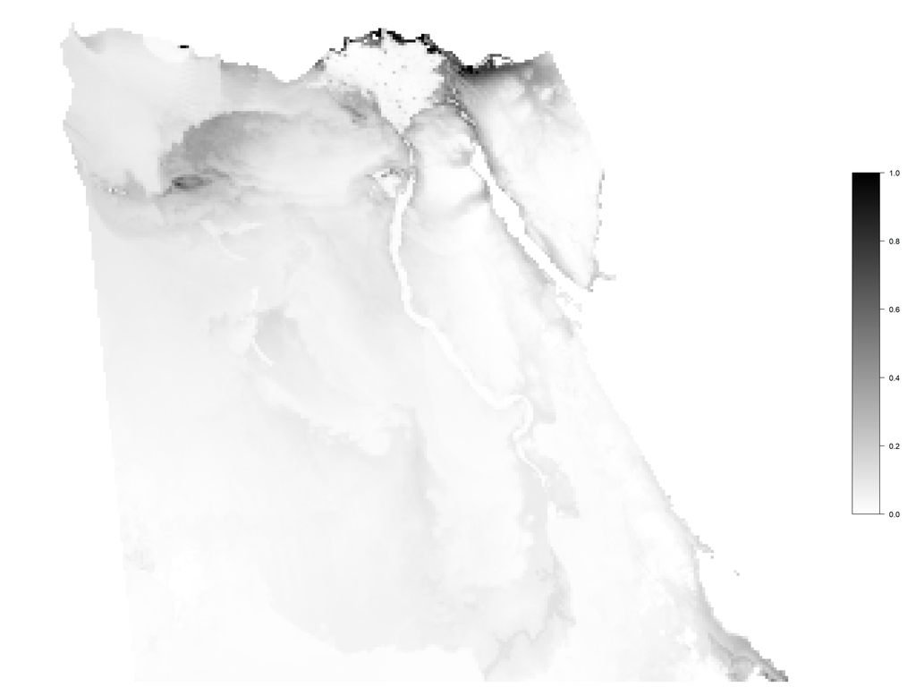

#### D. **Cost layer**

- The file `ZigInputFiles/Maps/CostLayer.tif` identifieS urban areas to be given low priority.

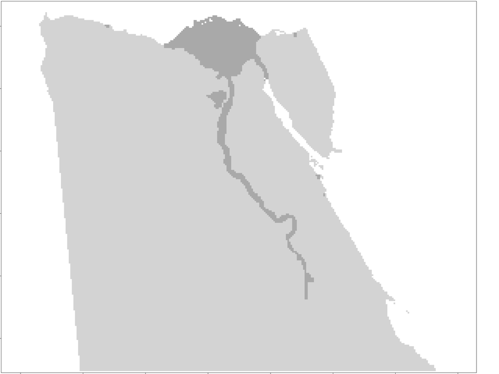

#### E. **Current Protected Areas**

- The file `ZigInputFiles/Maps/Mask_PAs.tif` discriminates the Egyptian Protected Areas from other areas.

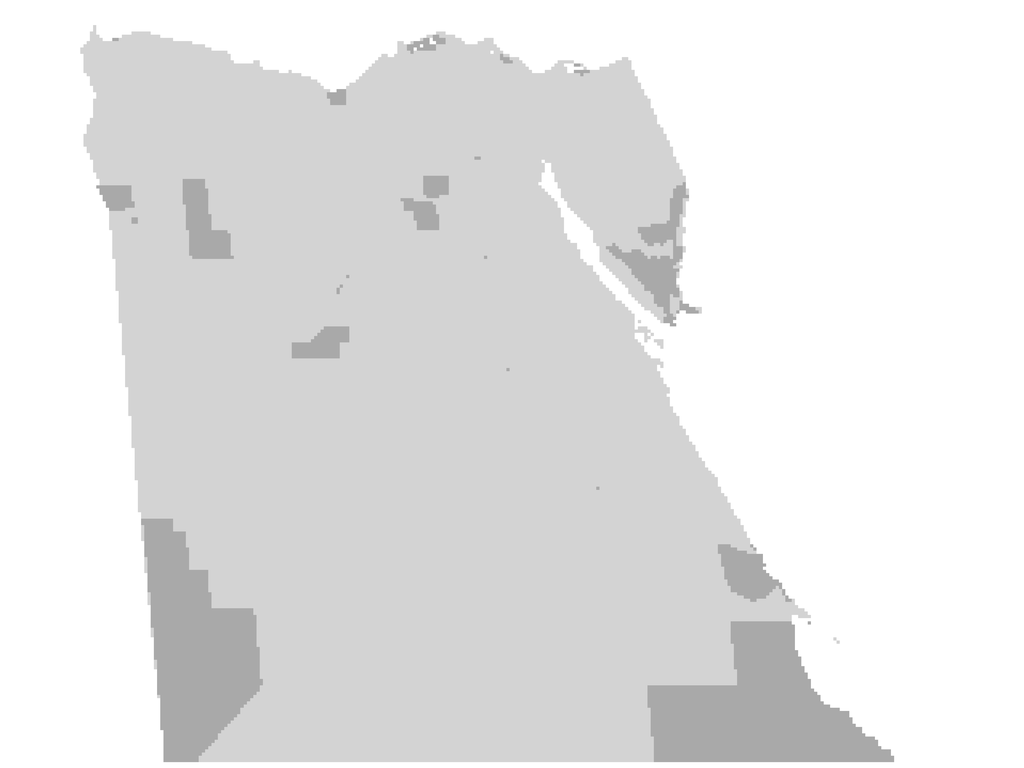

#### F. **Response curve**

- This file `ZigInputFiles/Maps/BQPcurves.txt` contains data for different BQP curves used.

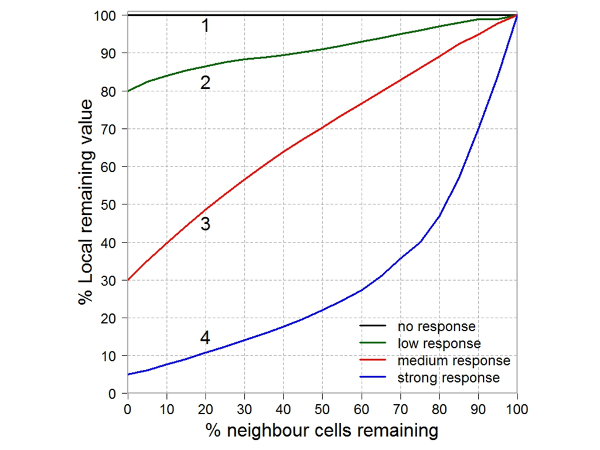

## 2. Preparing feature list files `(.spp)`

> The feature list file `(.spp)` includes a list of all biodiversity features (species, ecosystems, etc.) included in the analysis. This file is a text file that can be created in Notepad. [The file name extension .spp is not compulsory but we often use it to indicate that the file is a Zonation “species list file”.] Each row in the file corresponds to a biodiversity feature. For each biodiversity feature, there are six columns of information which require values to be entered. Frequently, dummy values are used in columns that are not relevant for the particular case. (Di Minin et al. 2014)

An example `.spp` file is shown below. For more information, see (Di Minin et al. 2014)

```
1   1   2   1   1   ZigInputFiles/Maps/En_Bias0/En_Bias0_Sp1.tif
1   1   2   1   1   ZigInputFiles/Maps/En_Bias0/En_Bias0_Sp2.tif
3   1   2   1   1   ZigInputFiles/Maps/En_Bias0/En_Bias0_Sp3.tif
3   1   2   1   1   ZigInputFiles/Maps/En_Bias0/En_Bias0_Sp4.tif
1   1   2   1   1   ZigInputFiles/Maps/En_Bias0/En_Bias0_Sp5.tif
3   1   2   1   1   ZigInputFiles/Maps/En_Bias0/En_Bias0_Sp6.tif
3   1   2   1   1   ZigInputFiles/Maps/En_Bias0/En_Bias0_Sp7.tif
1   1   2   1   1   ZigInputFiles/Maps/En_Bias0/En_Bias0_Sp8.tif
1   1   2   1   1   ZigInputFiles/Maps/En_Bias0/En_Bias0_Sp9.tif
1   1   2   1   1   ZigInputFiles/Maps/En_Bias0/En_Bias0_Sp10.tif
1   1   2   1   1   ZigInputFiles/Maps/En_Bias0/En_Bias0_Sp11.tif
1   1   2   1   1   ZigInputFiles/Maps/En_Bias0/En_Bias0_Sp12.tif
3   1   2   1   1   ZigInputFiles/Maps/En_Bias0/En_Bias0_Sp13.tif
1   1   2   1   1   ZigInputFiles/Maps/En_Bias0/En_Bias0_Sp14.tif
3   1   2   1   1   ZigInputFiles/Maps/En_Bias0/En_Bias0_Sp15.tif
```

The following code creates 640 `.spp` files: 4 weights × 10 BQP combinations × 2 Modelling algorithms × 2 Sampling bias scenarios × 4 surrogate options

### 2.1. Preparing file names

The four weighting options are:

- `WTWO-NoUncert`: no weighting; without predictive uncertainty
- `WTLoc-NoUncert`: weighting with national red-list status weighting; without predictive uncertainty
- `WTWO-Uncert`: no weighting; with predictive uncertainty
- `WTLoc-Uncert` : weighting with national red-list status weighting; with predictive uncertainty

```r
Weights <- c("WTWO-NoUncert", "WTLoc-NoUncert", "WTWO-Uncert", "WTLoc-Uncert")
```

Four BQP curves and 3 radii

```r
BQP_Curve <- expand.grid(c("BQP-WO", "BQP-Low", "BQP-Med", "BQP-Strng"), 1:3)
BQP_Curve <- paste0(BQP_Curve[,1], "-", BQP_Curve[,2])
BQP_Curve <- BQP_Curve[!BQP_Curve %in% c("BQP-WO-2", "BQP-WO-3")]
```

Two Modelling algorithms × 2 Sampling bias scenarios × 4 surrogate options

```r
SpeciesMaps <- expand.grid(c("Mxnt", "EN"), c("BiasWO", "Bias0"), c("MMls", "Rep", "Butr", "AllSP"))
SpeciesMaps <- paste0(SpeciesMaps[,1], "-", SpeciesMaps[,2], "-", SpeciesMaps[,3])
AllSppFiles <- expand.grid(Weights = Weights, BQP_Curve = BQP_Curve, SpeciesMaps = SpeciesMaps)
AllSppFiles <- paste0(AllSppFiles[,1], "__", AllSppFiles[,2], "__", AllSppFiles[,3], ".spp")
```

The names of the 640 `spp` files:

| AllSppFiles |
| --- |
| WTWO-NoUncert__BQP-WO-1__Mxnt-BiasWO-MMls.spp |
| WTLoc-NoUncert__BQP-WO-1__Mxnt-BiasWO-MMls.spp |
| WTWO-Uncert__BQP-WO-1__Mxnt-BiasWO-MMls.spp |
| WTLoc-Uncert__BQP-WO-1__Mxnt-BiasWO-MMls.spp |
| WTWO-NoUncert__BQP-Low-1__Mxnt-BiasWO-MMls.spp |
| WTLoc-NoUncert__BQP-Low-1__Mxnt-BiasWO-MMls.spp |
| WTWO-Uncert__BQP-Low-1__Mxnt-BiasWO-MMls.spp |
| WTLoc-Uncert__BQP-Low-1__Mxnt-BiasWO-MMls.spp |
| WTWO-NoUncert__BQP-Med-1__Mxnt-BiasWO-MMls.spp |
| WTLoc-NoUncert__BQP-Med-1__Mxnt-BiasWO-MMls.spp |

[output cut: 630 more lines]

Each `.spp` file has different number of rows based on the number of species: 5 species for analyses of each of butterflies, reptiles, and mammals; 15 species for all species analysis.

```r
AllSppData <- vector(mode = "list", length = length(AllSppFiles))
names(AllSppData) <- AllSppFiles

Index_AllSP <- grep(pattern = "AllSP", x = names(AllSppData))
Index_MMls <- grep(pattern = "MMls", x = names(AllSppData))
Index_Rep <- grep(pattern = "Rep", x = names(AllSppData))
Index_Butr <- grep(pattern = "Butr", x = names(AllSppData))

for(i in Index_AllSP){ AllSppData[[i]] <- data.frame(matrix(ncol = 6, nrow = 15)) }
for(i in c(Index_MMls, Index_Rep, Index_Butr)){ AllSppData[[i]] <- data.frame(matrix(ncol = 6, nrow = 5)) }

# renaming columns
AllSppData <- lapply(AllSppData, FUN = function(x){
  names(x) <- c("Weight", "Alpha", "BQP_CurveNum", "BQP_Buff", "ABF_Rate", "SpeciesMaps")
  x$Alpha <- 1
  x$ABF_Rate <- 1
  x
})
```

Next, we change the options within each of the 640 `.spp` files

- BQP radius
- BQP response curves
- Species
- Weights

### 2.2. BQP radius options

```r
Index_BQP_Buff1 <- grep(pattern = "__BQP-.*-1__", x = names(AllSppData))
for(i in Index_BQP_Buff1){ AllSppData[[i]]$BQP_Buff <- 1 }

Index_BQP_Buff2 <- grep(pattern = "__BQP-.*-2__", x = names(AllSppData))
for(i in Index_BQP_Buff2){ AllSppData[[i]]$BQP_Buff <- 2 }

Index_BQP_Buff3 <- grep( pattern = "__BQP-.*-3__", x = names(AllSppData))
for(i in Index_BQP_Buff3){ AllSppData[[i]]$BQP_Buff <- 3 }
```

### 2.3. BQP response curves options

```r
BQP_CurveNum1 <- grep(pattern = "BQP-WO", x = names(AllSppData))
for(i in BQP_CurveNum1){ AllSppData[[i]]$BQP_CurveNum <- 1 }

BQP_CurveNum2 <- grep(pattern = "BQP-Low", x = names(AllSppData))
for(i in BQP_CurveNum2){ AllSppData[[i]]$BQP_CurveNum <- 2 }

BQP_CurveNum3 <- grep(pattern = "BQP-Med", x = names(AllSppData))
for(i in BQP_CurveNum3){ AllSppData[[i]]$BQP_CurveNum <- 3 }

BQP_CurveNum4 <- grep(pattern = "BQP-Strng", x = names(AllSppData))
for(i in BQP_CurveNum4){ AllSppData[[i]]$BQP_CurveNum <- 4 }
```

### 2.4. Species options

In this example, there are 5 species for each group. Species 1:5 for reptiles; Species 6:10 for butterflies; 11:15 for mammals

#### *1. All species*

```r
SpNums <- 1:15

#-------------------------

FileNames_AllSp_Mxnt_NoBias <- paste0("ZigInputFiles/Maps/Mxnt_NoBias/Mxnt_NoBias_Sp", SpNums, ".tif")
Index_AllSP_Mxnt_NoBias <- grep(pattern = "Mxnt-BiasWO-AllSP", x = names(AllSppData))
for (i in Index_AllSP_Mxnt_NoBias){ AllSppData[[i]]$SpeciesMaps <- FileNames_AllSp_Mxnt_NoBias }

#-------------------------

FileNames_AllSp_Mxnt_Bias0 <- paste0("ZigInputFiles/Maps/Mxnt_Bias0/Mxnt_Bias0_Sp", SpNums, ".tif")
Index_AllSP_Mxnt_Bias0 <- grep(pattern = "Mxnt-Bias0-AllSP", x = names(AllSppData))
for (i in Index_AllSP_Mxnt_Bias0){ AllSppData[[i]]$SpeciesMaps <- FileNames_AllSp_Mxnt_Bias0 }

#-------------------------

FileNames_AllSp_En_NoBias <- paste0("ZigInputFiles/Maps/En_NoBias/En_NoBias_Sp", SpNums, ".tif")
Index_AllSP_En_NoBias <- grep(pattern = "EN-BiasWO-AllSP", x = names(AllSppData))
for (i in Index_AllSP_En_NoBias){ AllSppData[[i]]$SpeciesMaps <- FileNames_AllSp_En_NoBias }

#-------------------------

FileNames_AllSp_En_Bias0 <- paste0("ZigInputFiles/Maps/En_Bias0/En_Bias0_Sp", SpNums, ".tif")
Index_AllSP_En_Bias0 <- grep(pattern = "EN-Bias0-AllSP", x = names(AllSppData))
for (i in Index_AllSP_En_Bias0){ AllSppData[[i]]$SpeciesMaps <- FileNames_AllSp_En_Bias0 }
```

#### *2. Reptiles*

```r
SpNums <- 1:5

#-------------------------

FileNames_REPT_Mxnt_NoBias <- paste0("ZigInputFiles/Maps/Mxnt_NoBias/Mxnt_NoBias_Sp", SpNums, ".tif")
Index_REPT_Mxnt_NoBias <- grep(pattern = "Mxnt-BiasWO-Rep", x = names(AllSppData))
for (i in Index_REPT_Mxnt_NoBias){ AllSppData[[i]]$SpeciesMaps <- FileNames_REPT_Mxnt_NoBias }

#-------------------------

FileNames_REPT_Mxnt_Bias0 <- paste0("ZigInputFiles/Maps/Mxnt_Bias0/Mxnt_Bias0_Sp", SpNums, ".tif")
Index_REPT_Mxnt_Bias0 <- grep(pattern = "Mxnt-Bias0-Rep", x = names(AllSppData))
for (i in Index_REPT_Mxnt_Bias0){ AllSppData[[i]]$SpeciesMaps <- FileNames_REPT_Mxnt_Bias0 }

#-------------------------

FileNames_REPT_En_NoBias <- paste0("ZigInputFiles/Maps/En_NoBias/En_NoBias_Sp", SpNums, ".tif")
Index_REPT_En_NoBias <- grep(pattern = "EN-BiasWO-Rep", x = names(AllSppData))
for (i in Index_REPT_En_NoBias){ AllSppData[[i]]$SpeciesMaps <- FileNames_REPT_En_NoBias }

#-------------------------

FileNames_REPT_En_Bias0 <- paste0( "ZigInputFiles/Maps/En_Bias0/En_Bias0_Sp", SpNums, ".tif")
Index_REPT_En_Bias0 <- grep(pattern = "EN-Bias0-Rep", x = names(AllSppData))
for (i in Index_REPT_En_Bias0){ AllSppData[[i]]$SpeciesMaps <- FileNames_REPT_En_Bias0 }
```

#### *3. Butterflies*

```r
SpNums <- 6:10

#-------------------------

FileNames_BTTR_Mxnt_NoBias <- paste0("ZigInputFiles/Maps/Mxnt_NoBias/Mxnt_NoBias_Sp", SpNums, ".tif")
Index_BTTR_Mxnt_NoBias <- grep(pattern = "Mxnt-BiasWO-Butr", x = names(AllSppData))
for (i in Index_BTTR_Mxnt_NoBias){ AllSppData[[i]]$SpeciesMaps <- FileNames_BTTR_Mxnt_NoBias }

#-------------------------

FileNames_BTTR_Mxnt_Bias0 <- paste0("ZigInputFiles/Maps/Mxnt_Bias0/Mxnt_Bias0_Sp", SpNums, ".tif")
Index_BTTR_Mxnt_Bias0 <- grep(pattern = "Mxnt-Bias0-Butr", x = names(AllSppData))
for (i in Index_BTTR_Mxnt_Bias0){ AllSppData[[i]]$SpeciesMaps <- FileNames_BTTR_Mxnt_Bias0 }

#-------------------------

FileNames_BTTR_En_NoBias <- paste0("ZigInputFiles/Maps/En_NoBias/En_NoBias_Sp", SpNums, ".tif")
Index_BTTR_En_NoBias <- grep(pattern = "EN-BiasWO-Butr", x = names(AllSppData))
for (i in Index_BTTR_En_NoBias){ AllSppData[[i]]$SpeciesMaps <- FileNames_BTTR_En_NoBias }

#-------------------------

FileNames_BTTR_En_Bias0 <- paste0("ZigInputFiles/Maps/En_Bias0/En_Bias0_Sp", SpNums, ".tif")
Index_BTTR_En_Bias0 <- grep(pattern = "EN-Bias0-Butr", x = names(AllSppData))
for (i in Index_BTTR_En_Bias0){ AllSppData[[i]]$SpeciesMaps <- FileNames_BTTR_En_Bias0 }
```

#### *4. Mammals*

```r
SpNums <- 11:15

#-------------------------

FileNames_MMLS_Mxnt_NoBias <- paste0("ZigInputFiles/Maps/Mxnt_NoBias/Mxnt_NoBias_Sp", SpNums, ".tif")
Index_MMLS_Mxnt_NoBias <- grep(pattern = "Mxnt-BiasWO-MMls", x = names(AllSppData))
for (i in Index_MMLS_Mxnt_NoBias){ AllSppData[[i]]$SpeciesMaps <- FileNames_MMLS_Mxnt_NoBias }

#-------------------------

FileNames_MMLS_Mxnt_Bias0 <- paste0("ZigInputFiles/Maps/Mxnt_Bias0/Mxnt_Bias0_Sp", SpNums, ".tif")
Index_MMLS_Mxnt_Bias0 <- grep(pattern = "Mxnt-Bias0-MMls", x = names(AllSppData))
for (i in Index_MMLS_Mxnt_Bias0){ AllSppData[[i]]$SpeciesMaps <- FileNames_MMLS_Mxnt_Bias0 }

#-------------------------

FileNames_MMLS_En_NoBias <- paste0("ZigInputFiles/Maps/En_NoBias/En_NoBias_Sp", SpNums, ".tif")
Index_MMLS_En_NoBias <- grep(pattern = "EN-BiasWO-MMls", x = names(AllSppData))
for (i in Index_MMLS_En_NoBias){ AllSppData[[i]]$SpeciesMaps <- FileNames_MMLS_En_NoBias }

#-------------------------

FileNames_MMLS_En_Bias0 <- paste0("ZigInputFiles/Maps/En_Bias0/En_Bias0_Sp", SpNums, ".tif")
Index_MMLS_En_Bias0 <- grep(pattern = "EN-Bias0-MMls", x = names(AllSppData))
for (i in Index_MMLS_En_Bias0){ AllSppData[[i]]$SpeciesMaps <- FileNames_MMLS_En_Bias0 }
```

### 2.5. Weight options

These files contain the different values of per-species weight

```r
WeightsData_EN_Bias0 <- read.csv("ZigInputFiles/Data/WeightsData_EN_Bias0.csv", sep = ",", header = T)
WeightsData_EN_WOBias <- read.csv("ZigInputFiles/Data/WeightsData_EN_WOBias.csv", sep = ",", header = T)
WeightsData_Mxnt_Bias0 <- read.csv("ZigInputFiles/Data/WeightsData_Mxnt_Bias0.csv", sep = ",", header = T)
WeightsData_Mxnt_WOBias <- read.csv("ZigInputFiles/Data/WeightsData_Mxnt_WOBias.csv", sep = ",", header = T)
```

#### *2.5.1. No predictive uncertainty & No Red-List weight*

```r
Index_WTWO_NoUncert <- grep(pattern = "WTWO-NoUncert", x = names(AllSppData))

for (i in Index_WTWO_NoUncert){
  ifelse(
    grepl(pattern = "AllSP", x = names(AllSppData[i])),
    AllSppData[[i]]$Weight <- WeightsData_Mxnt_WOBias$WT_WO,

    ifelse(
      grepl(pattern = "Rep", x = names(AllSppData[i])),
      AllSppData[[i]]$Weight <-
        WeightsData_Mxnt_WOBias$WT_WO[1:5],

      ifelse(
        grepl(pattern = "Butr", x = names(AllSppData[i])),
        AllSppData[[i]]$Weight <-
          WeightsData_Mxnt_WOBias$WT_WO[6:10],

        ifelse(
          grepl(pattern = "MMls", x = names(AllSppData[i])),
          AllSppData[[i]]$Weight <-
            WeightsData_Mxnt_WOBias$WT_WO[11:15],
          print("ERROR")))))
}
```

#### *2.5.2. No predictive uncertainty & with Red-List weight*

```r
Index_WTLoc_NoUncert <- grep(pattern = "WTLoc-NoUncert", x = names(AllSppData))

for (i in Index_WTLoc_NoUncert){
  ifelse(
    grepl(pattern = "AllSP", x = names(AllSppData[i])),
    AllSppData[[i]]$Weight <-
      WeightsData_Mxnt_WOBias$WT_Local,

    ifelse(
      grepl(pattern = "Rep", x = names(AllSppData[i])),
      AllSppData[[i]]$Weight <-
        WeightsData_Mxnt_WOBias$WT_Local[1:5],

      ifelse(
        grepl(pattern = "Butr", x = names(AllSppData[i])),
        AllSppData[[i]]$Weight <-
          WeightsData_Mxnt_WOBias$WT_Local[6:10],

        ifelse(
          grepl(pattern = "MMls", x = names(AllSppData[i])),
          AllSppData[[i]]$Weight <-
            WeightsData_Mxnt_WOBias$WT_Local[11:15],
          print("ERROR")))))
}
```

#### *2.5.3. With predictive uncertainty & No Red-List weight*

*A. With no sampling bias | Maxent*

```r
Index_WTWO_Uncert_Mxnt_BiasWO <- grep(pattern = "WTWO-Uncert.*Mxnt-BiasWO", x = names(AllSppData))

for (i in Index_WTWO_Uncert_Mxnt_BiasWO){
  ifelse(
    grepl(pattern = "AllSP", x = names(AllSppData[i])),
    AllSppData[[i]]$Weight <- WeightsData_Mxnt_WOBias$WT_WO_Uncert,

    ifelse(
      grepl(pattern = "Rep", x = names(AllSppData[i])),
      AllSppData[[i]]$Weight <- WeightsData_Mxnt_WOBias$WT_WO_Uncert[1:5],

      ifelse(
        grepl(pattern = "Butr", x = names(AllSppData[i])),
        AllSppData[[i]]$Weight <- WeightsData_Mxnt_WOBias$WT_WO_Uncert[6:10],

        ifelse(
          grepl(pattern = "MMls", x = names(AllSppData[i])),
          AllSppData[[i]]$Weight <- WeightsData_Mxnt_WOBias$WT_WO_Uncert[11:15],
          print("ERROR")))))
}
```

*B. With no sampling bias | Elastic net*

```r
Index_WTWO_Uncert_EN_BiasWO <- grep(pattern = "WTWO-Uncert.*EN-BiasWO", x = names(AllSppData))

for (i in Index_WTWO_Uncert_EN_BiasWO){
  ifelse(
    grepl(pattern = "AllSP", x = names(AllSppData[i])),
    AllSppData[[i]]$Weight <- WeightsData_EN_WOBias$WT_WO_Uncert,

    ifelse(
      grepl(pattern = "Rep", x = names(AllSppData[i])),
      AllSppData[[i]]$Weight <- WeightsData_EN_WOBias$WT_WO_Uncert[1:5],

      ifelse(
        grepl(pattern = "Butr", x = names(AllSppData[i])),
        AllSppData[[i]]$Weight <- WeightsData_EN_WOBias$WT_WO_Uncert[6:10],

        ifelse(
          grepl(pattern = "MMls", x = names(AllSppData[i])),
          AllSppData[[i]]$Weight <- WeightsData_EN_WOBias$WT_WO_Uncert[11:15],
          print("ERROR")))))
}
```

*C. With correction for sampling bias | Maxent*

```r
Index_WTWO_Uncert_Mxnt_Bias0 <- grep(pattern = "WTWO-Uncert.*Mxnt-Bias0", x = names(AllSppData))

for (i in Index_WTWO_Uncert_Mxnt_Bias0){
  ifelse(
    grepl(pattern = "AllSP", x = names(AllSppData[i])),
    AllSppData[[i]]$Weight <- WeightsData_Mxnt_Bias0$WT_WO_Uncert,

    ifelse(
      grepl(pattern = "Rep", x = names(AllSppData[i])),
      AllSppData[[i]]$Weight <- WeightsData_Mxnt_Bias0$WT_WO_Uncert[1:5],

      ifelse(
        grepl(pattern = "Butr", x = names(AllSppData[i])),
        AllSppData[[i]]$Weight <- WeightsData_Mxnt_Bias0$WT_WO_Uncert[6:10],

        ifelse(
          grepl(pattern = "MMls", x = names(AllSppData[i])),
          AllSppData[[i]]$Weight <- WeightsData_Mxnt_Bias0$WT_WO_Uncert[11:15],
          print("ERROR")))))
}
```

*D. With correction for sampling bias | Elastic net*

```r
Index_WTWO_Uncert_EN_Bias0 <- grep(pattern = "WTWO-Uncert.*EN-Bias0", x = names(AllSppData))

for (i in Index_WTWO_Uncert_EN_Bias0){
  ifelse(
    grepl(pattern = "AllSP", x = names(AllSppData[i])),
    AllSppData[[i]]$Weight <- WeightsData_EN_Bias0$WT_WO_Uncert,

    ifelse(
      grepl(pattern = "Rep", x = names(AllSppData[i])),
      AllSppData[[i]]$Weight <- WeightsData_EN_Bias0$WT_WO_Uncert[1:5],

      ifelse(
        grepl(pattern = "Butr", x = names(AllSppData[i])),
        AllSppData[[i]]$Weight <- WeightsData_EN_Bias0$WT_WO_Uncert[6:10],

        ifelse(
          grepl(pattern = "MMls", x = names(AllSppData[i])),
          AllSppData[[i]]$Weight <- WeightsData_EN_Bias0$WT_WO_Uncert[11:15],
          print("ERROR")))))
}
```

#### *2.5.4. With predictive uncertainty & Red-List weight*

*A. With no sampling bias | Maxent*

```r
Index_WTLoc_Uncert_Mxnt_BiasWO <- grep(pattern = "WTLoc-Uncert.*Mxnt-BiasWO", x = names(AllSppData))

for (i in Index_WTLoc_Uncert_Mxnt_BiasWO){
  ifelse(
    grepl(pattern = "AllSP", x = names(AllSppData[i])),
    AllSppData[[i]]$Weight <- WeightsData_Mxnt_WOBias$WT_Local_Uncert,

    ifelse(
      grepl(pattern = "Rep", x = names(AllSppData[i])),
      AllSppData[[i]]$Weight <- WeightsData_Mxnt_WOBias$WT_Local_Uncert[1:5],

      ifelse(
        grepl(pattern = "Butr", x = names(AllSppData[i])),
        AllSppData[[i]]$Weight <- WeightsData_Mxnt_WOBias$WT_Local_Uncert[6:10],

        ifelse(
          grepl(pattern = "MMls", x = names(AllSppData[i])),
          AllSppData[[i]]$Weight <- WeightsData_Mxnt_WOBias$WT_Local_Uncert[11:15],
          print("ERROR")))))
}
```

*B. With no sampling bias | Elastic net*

```r
Index_WTLoc_Uncert_EN_BiasWO <- grep(pattern = "WTLoc-Uncert.*EN-BiasWO", x = names(AllSppData))

for (i in Index_WTLoc_Uncert_EN_BiasWO){
  ifelse(
    grepl(pattern = "AllSP", x = names(AllSppData[i])),
    AllSppData[[i]]$Weight <- WeightsData_EN_WOBias$WT_Local_Uncert,

    ifelse(
      grepl(pattern = "Rep", x = names(AllSppData[i])),
      AllSppData[[i]]$Weight <- WeightsData_EN_WOBias$WT_Local_Uncert[1:5],

      ifelse(
        grepl(pattern = "Butr", x = names(AllSppData[i])),
        AllSppData[[i]]$Weight <- WeightsData_EN_WOBias$WT_Local_Uncert[6:10],

        ifelse(
          grepl(pattern = "MMls", x = names(AllSppData[i])),
          AllSppData[[i]]$Weight <- WeightsData_EN_WOBias$WT_Local_Uncert[11:15],
          print("ERROR")))))
}
```

*C. With correction for sampling bias | Maxent*

```r
Index_WTLoc_Uncert_Mxnt_Bias0 <- grep(pattern = "WTLoc-Uncert.*Mxnt-Bias0", x = names(AllSppData))

for (i in Index_WTLoc_Uncert_Mxnt_Bias0){
  ifelse(
    grepl(pattern = "AllSP", x = names(AllSppData[i])),
    AllSppData[[i]]$Weight <- WeightsData_Mxnt_Bias0$WT_Local_Uncert,

    ifelse(
      grepl(pattern = "Rep", x = names(AllSppData[i])),
      AllSppData[[i]]$Weight <- WeightsData_Mxnt_Bias0$WT_Local_Uncert[1:5],

      ifelse(
        grepl(pattern = "Butr", x = names(AllSppData[i])),
        AllSppData[[i]]$Weight <- WeightsData_Mxnt_Bias0$WT_Local_Uncert[6:10],

        ifelse(
          grepl(pattern = "MMls", x = names(AllSppData[i])),
          AllSppData[[i]]$Weight <- WeightsData_Mxnt_Bias0$WT_Local_Uncert[11:15],
          print("ERROR")))))
}
```

*D. With correction for sampling bias | Elastic net*

```r
Index_WTLoc_Uncert_EN_Bias0 <- grep(pattern = "WTLoc-Uncert.*EN-Bias0", x = names(AllSppData))

for (i in Index_WTLoc_Uncert_EN_Bias0){
  ifelse(
    grepl(pattern = "AllSP", x = names(AllSppData[i])),
    AllSppData[[i]]$Weight <- WeightsData_EN_Bias0$WT_Local_Uncert,

    ifelse(
      grepl(pattern = "Rep", x = names(AllSppData[i])),
      AllSppData[[i]]$Weight <- WeightsData_EN_Bias0$WT_Local_Uncert[1:5],

      ifelse(
        grepl(pattern = "Butr", x = names(AllSppData[i])),
        AllSppData[[i]]$Weight <- WeightsData_EN_Bias0$WT_Local_Uncert[6:10],

        ifelse(
          grepl(pattern = "MMls", x = names(AllSppData[i])),
          AllSppData[[i]]$Weight <- WeightsData_EN_Bias0$WT_Local_Uncert[11:15],
          print("ERROR")))))
}
```

### 2.6. Exporting `.spp` files

```r
for (i in 1:length(AllSppData)){
  write.table(
    x = AllSppData[[i]],
    file = paste0("output_spp/", names(AllSppData[i])),
    sep = "\t", row.names = FALSE, col.names = FALSE)
}
```

## 4. Preparing project files [`.sh` or `.bat` files]

The project file specifies two main input files and the output files. (Di Minin et al. 2014)

### 4.1. Centos Linux cluster

Example `.sh` file:

```
#!/bin/bash
zig4 -r "ABF_Mask.dat" "WTLoc-NoUncert__BQP-Low-1__EN-Bias0-AllSP.spp" "output/ABF_Mask__WTLoc-NoUncert__BQP-Low-1__EN-Bias0-AllSP.txt" 0 1 1 1 --use-threads=16
```

- These `.sh` files were prepared to work in a *Centos Linux cluster* servers; using Slurm Workload Manager.
- This code produce one `.sh` file for each combination of `spp` and `dat` file will be prepared.
- the argument `--use-threads` in the next code chunk represents the number of parallel computaions of `Zonation`.

```r
SppFiles <- list.files(path = "output_spp\\", pattern = ".*.spp", full.names = FALSE)
SppFilesInit <- gsub(pattern = ".spp", replacement = "", x = SppFiles)

datFiles <- list.files(path = "ZigInputFiles\\Dat\\", pattern = ".*.dat", full.names=FALSE)
datFilesInit <- gsub(pattern = ".dat", replacement = "", x = datFiles)

AllShFiles <- expand.grid(dat = datFilesInit, spp = SppFilesInit, stringsAsFactors = FALSE)
AllShFiles$sh <- paste0(AllShFiles$dat, "__", AllShFiles$spp, ".sh")
AllShFiles$OutFile <- paste0("output/", AllShFiles$dat, "__", AllShFiles$spp, ".txt")
AllShFiles$dat <- paste0(AllShFiles$dat, ".dat")
AllShFiles$spp <- paste0(AllShFiles$spp, ".spp")

for (i in 1:nrow(AllShFiles)){
  Currdat <- AllShFiles[i,"dat"]
  CurrSpp <- AllShFiles[i,"spp"]
  CurrOutSh <- AllShFiles[i,"sh"]
  CurrOutTxt <- AllShFiles[i,"OutFile"]

  cat(paste0(
    '#!/bin/bash\nzig4 -r "',
    Currdat, '" "', CurrSpp, '" "',
    CurrOutTxt, '" ', '0 1 1 1 --use-threads=16'),
    file = paste0("output_sh\\", CurrOutSh))

  rm(Currdat, CurrSpp, CurrOutSh, CurrOutTxt)
}
```

Now, there should be 2,560 `.sh` files:

- 4 surrogate taxa (butterflies *vs* reptiles *vs* mammals *vs* the three groups together)
- 2 modelling algorithms (Maxent *vs* elastic net)
- 2 biases (without *vs* with sampling-bias correction)
- 2 cell-removal rules (ABF *vs* CAZ)
- 4 weighting schemes (with *vs* without Red-List or predictive-uncertainty weights)
- 10 connectivity options
- 2 PA-integration options (without *vs* with PA masking)

### 4.2. Windows PC

Example `.bat` file:

```
call zig4.exe -r "ABF_Mask.dat" "WTLoc-NoUncert__BQP-Low-1__EN-Bias0-AllSP.spp" "output/ABF_Mask__WTLoc-NoUncert__BQP-Low-1__EN-Bias0-AllSP.txt" 0 1 1 1 --use-threads=16
```

This is a similar code to produce `.bat` files to work under windows environment

```r
AllShFiles$bat <- paste0(
  gsub(pattern = ".dat", replacement = "", x = AllShFiles$dat), "__",
  gsub(pattern = ".spp", replacement = "", x = AllShFiles$spp), ".bat")

for (i in 1:nrow(AllShFiles)){
  Currdat <- AllShFiles[i,"dat"]
  CurrSpp <- AllShFiles[i,"spp"]
  CurrOutBat <- AllShFiles[i,"bat"]
  CurrOutTxt <- AllShFiles[i,"OutFile"]

  cat(
    paste0('call zig4.exe -r "', Currdat, '" "', CurrSpp,
           '" "', CurrOutTxt, '" ', '0 1 1 1 --use-threads=16'),
    file = paste0("output_bat\\", CurrOutBat))

  rm(Currdat, CurrSpp, CurrOutBat, CurrOutTxt)
}
```

## 5. Running analyses on parallel

This code creates `.moab` files to facilitate the parallel run of 2,560 `Zonation` runs on a *Centos Linux cluster*  
An example `.moab` file:

```
#!/bin/sh
########### Begin MOAB/Slurm header ##########
#
# Give job a reasonable name
#MOAB -N Task_1
#
# Request number of nodes and CPU cores per node for job
#MOAB -l nodes=1:ppn=16, pmem=48gb
#
# Estimated wallclock time for job
#MOAB -l walltime=00:12:00:00
#
# Write standard output and errors in same file
#MOAB -j oe
#
# Send mail when job begins, aborts and ends
#MOAB -m bae
#
########### End MOAB header ##########

echo "Working Directory:                    $PWD"
echo "Running on host                       $HOSTNAME"
echo "Job id:                               $MOAB_JOBID"
echo "Job name:                             $MOAB_JOBNAME"
echo "Number of nodes allocated to job:     $MOAB_NODECOUNT"
echo "Number of cores allocated to job:     $MOAB_PROCCOUNT"

module load geo/zonation/4.0.0
cd ZonationEgypt/

bash "ABF_MaskNo__WTLoc-NoUncert__BQP-Low-1__EN-Bias0-AllSP.sh" &
bash "ABF_MaskNo__WTLoc-NoUncert__BQP-Low-1__EN-Bias0-Butr.sh" &
bash "ABF_MaskNo__WTLoc-NoUncert__BQP-Low-1__EN-Bias0-MMls.sh" &
bash "ABF_MaskNo__WTLoc-NoUncert__BQP-Low-1__EN-Bias0-Rep.sh" &
bash "ABF_MaskNo__WTLoc-NoUncert__BQP-Low-1__EN-BiasWO-AllSP.sh" &
bash "ABF_MaskNo__WTLoc-NoUncert__BQP-Low-1__EN-BiasWO-Butr.sh" &
bash "ABF_MaskNo__WTLoc-NoUncert__BQP-Low-1__EN-BiasWO-MMls.sh" &
bash "ABF_MaskNo__WTLoc-NoUncert__BQP-Low-1__EN-BiasWO-Rep.sh" &
bash "ABF_MaskNo__WTLoc-NoUncert__BQP-Low-1__Mxnt-Bias0-AllSP.sh" &
bash "ABF_MaskNo__WTLoc-NoUncert__BQP-Low-1__Mxnt-Bias0-Butr.sh" &
bash "ABF_MaskNo__WTLoc-NoUncert__BQP-Low-1__Mxnt-Bias0-MMls.sh" &
bash "ABF_MaskNo__WTLoc-NoUncert__BQP-Low-1__Mxnt-Bias0-Rep.sh" &
bash "ABF_MaskNo__WTLoc-NoUncert__BQP-Low-1__Mxnt-BiasWO-AllSP.sh" &
bash "ABF_MaskNo__WTLoc-NoUncert__BQP-Low-1__Mxnt-BiasWO-Butr.sh" &
bash "ABF_MaskNo__WTLoc-NoUncert__BQP-Low-1__Mxnt-BiasWO-MMls.sh" &
bash "ABF_MaskNo__WTLoc-NoUncert__BQP-Low-1__Mxnt-BiasWO-Rep.sh" &
bash "ABF_MaskNo__WTLoc-NoUncert__BQP-Low-2__EN-Bias0-AllSP.sh" &
bash "ABF_MaskNo__WTLoc-NoUncert__BQP-Low-2__EN-Bias0-Butr.sh" &
bash "ABF_MaskNo__WTLoc-NoUncert__BQP-Low-2__EN-Bias0-MMls.sh" &
bash "ABF_MaskNo__WTLoc-NoUncert__BQP-Low-2__EN-Bias0-Rep.sh" &
wait
echo "All are complete"
```

### 5.1. Analyses without PAs masking

- This code split 1280 `Zonation` runs into 64 files, each run 20 `Zonation` run in parallel

```r
FirstRuns <- list.files(path = "output_sh\\", pattern = ".*.sh")
FirstRuns <- FirstRuns[grep(pattern = ".*_MaskNo__", x = FirstRuns)]
FirstRuns1 <- split(FirstRuns, ceiling(seq_along(1:length(FirstRuns))/20))
names(FirstRuns1) <- paste0("Task_", 1:64, ".moab")

for (ii in 1:length(FirstRuns1)){

  CurrFile <- paste0("output_moab\\", names(FirstRuns1)[ii])

  cat("#!/bin/sh\n", file = CurrFile, append = FALSE)

  cat(
    paste0(
      "########### Begin MOAB/Slurm header ##########\n
      #\n
      # Give job a reasonable name\n
      #MOAB -N Task_", 0+ii),
    file = CurrFile, append = TRUE)

  cat(
    paste0(
    '
    #
    # Request number of nodes and CPU cores per node for job
    #MOAB -l nodes=1:ppn=16, pmem=48gb
    #
    # Estimated wallclock time for job
    #MOAB -l walltime=00:12:00:00
    # Write standard output and errors in same file
    #MOAB -j oe
    #
    # Send mail when job begins, aborts and ends
    #MOAB -m bae
    #
    ########### End MOAB header ##########

    echo "Working Directory:                    $PWD"
    echo "Running on host                       $HOSTNAME"
    echo "Job id:                               $MOAB_JOBID"
    echo "Job name:                             $MOAB_JOBNAME"
    echo "Number of nodes allocated to job:     $MOAB_NODECOUNT"
    echo "Number of cores allocated to job:     $MOAB_PROCCOUNT"

    module load geo/zonation/4.0.0

    cd ZonationEgypt/'),

    file = CurrFile, append = TRUE)

  for(i in 1:length(FirstRuns1[[ii]])){
    cat(paste0('bash "', FirstRuns1[[ii]][i], '" &\n'), file = CurrFile, append = TRUE)
  }

  cat(paste0('wait\necho "All are complete"'), file = CurrFile, append = TRUE)
}

Tasks <- paste0("msub Task_", 1:128, ".moab")
cat(Tasks, file = "output_tasks\\Tasks1_128.txt", sep = "\n")
```

### 5.2. Analyses with PAs masking

- This code split 1280 `Zonation` runs into 64 files, each run 20 `Zonation` run in parallel

```r
FirstRuns <- list.files(path = "output_sh\\", pattern = ".*.sh")
FirstRuns <- FirstRuns[grep(pattern = ".*_Mask__", x = FirstRuns)]
FirstRuns1 <- split(FirstRuns, ceiling(seq_along(1:length(FirstRuns))/20))
names(FirstRuns1) <- paste0("Task_", 65:128, ".moab")

for (ii in 1:length(FirstRuns1)){

  CurrFile <- paste0("output_moab\\", names(FirstRuns1)[ii])

  cat("#!/bin/sh\n", file = CurrFile, append = FALSE)

  cat(
    paste0(
      "########### Begin MOAB/Slurm header ##########\n#\n
       # Give job a reasonable name\n
       #MOAB -N Task_", 64+ii),
    file = CurrFile, append = TRUE)

  cat(
    paste0('
    #
    # Request number of nodes and CPU cores per node for job
    #MOAB -l nodes=1:ppn=16, pmem=48gb
    #
    # Estimated wallclock time for job
    #MOAB -l walltime=00:12:00:00
    #
    # Write standard output and errors in same file
    #MOAB -j oe
    #
    # Send mail when job begins, aborts and ends
    #MOAB -m bae
    #
    ########### End MOAB header ##########

    echo "Working Directory:                    $PWD"
    echo "Running on host                       $HOSTNAME"
    echo "Job id:                               $MOAB_JOBID"
    echo "Job name:                             $MOAB_JOBNAME"
    echo "Number of nodes allocated to job:     $MOAB_NODECOUNT"
    echo "Number of cores allocated to job:     $MOAB_PROCCOUNT"

    module load geo/zonation/4.0.0

    cd ZonationEgypt/'),

  file = CurrFile, append = TRUE)

  for(i in 1:length(FirstRuns1[[ii]])){
    cat(paste0('bash "', FirstRuns1[[ii]][i], '" &\n'), file = CurrFile, append = TRUE)
  }

  cat(paste0('wait\necho "All are complete"'), file = CurrFile, append = TRUE)
}

Tasks <- paste0("msub Task_", 65:128, ".moab")
cat(Tasks, file = "output_tasks\\Tasks65_128.txt", sep = "\n")
```

## 6. References

Di Minin, Enrico, Victoria Veach, Joona Lehtomäki, Federico Montesino Pouzols, Atte Moilanen, and others. 2014. “A Quick Introduction to Zonation.”